# Catchability pattern exploration

Updated on Oct 23, 2022

## Density-dependent catchability pattern

- Create a density-dependent catchability pattern that follows a powered relationship ([Wilber and Bence, 2006](https://doi.org/10.1139/f06-111)) where catchability declined with increasing biomass of menhaden-like species
- $q_t = \alpha B_t^{-\beta}$ and $F_{t, a} = q_t E_t$

where $q_t$ denotes fishery catchability ($effort^{-1}$), $\alpha$ and $\beta$ represent parameters for density-dependent catchability. Medium values of $\alpha$ and $\beta$ can be 90 and 0.49 respectively ([Wilber and Bence, 2006](https://doi.org/10.1139/f06-111)). $F_{t,a}$ and $E_t$ represent instantaneous fishing mortality rate by age and year ($year^{-1}$) and fishery effort respectively.

## Simulation based on default catchability from the EwE OM

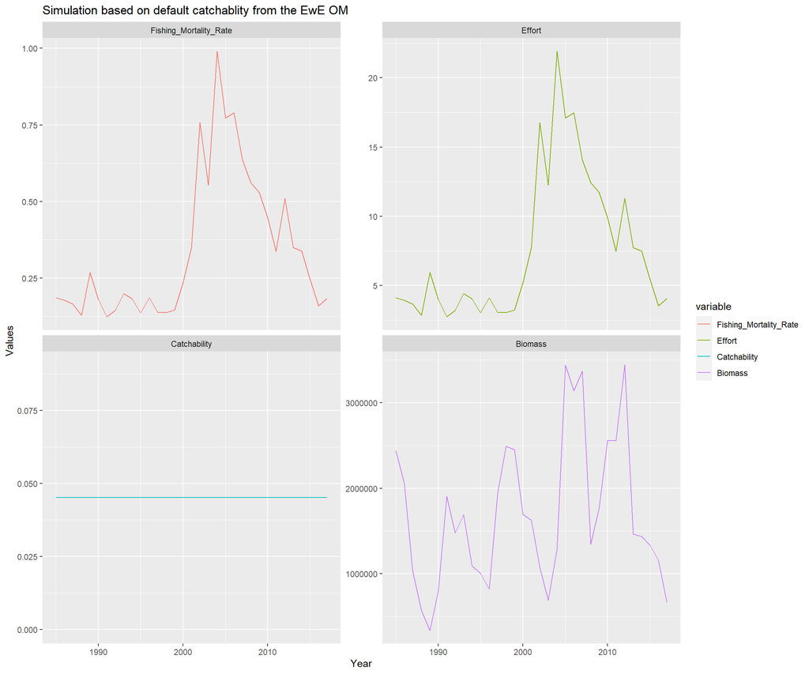

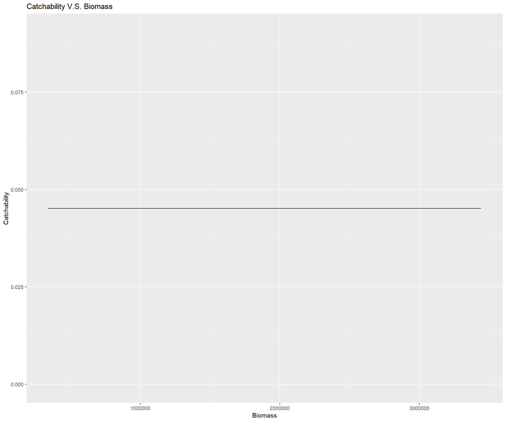

## Simulation based on density-dependent catchability

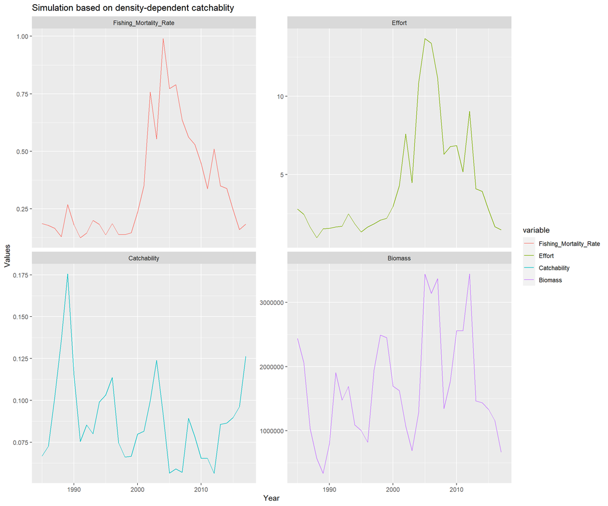

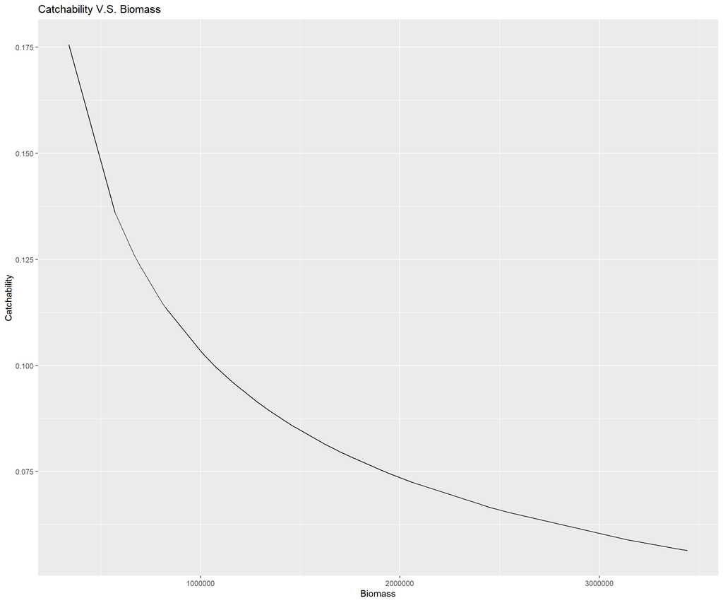

## I think effort is confounded by fishing mortality?

We can plot effort from both constant catchability (the OM) and density-dependent catchability below:

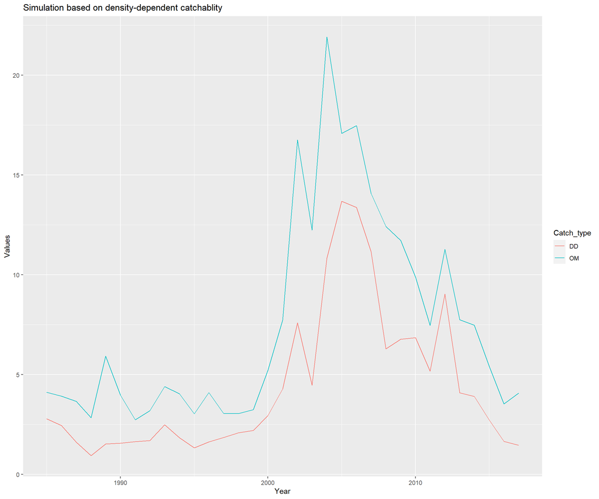

The scale is different but the trends still appear similar - I think this is because effort is still mostly following the trend from fishing mortality. This may make sense if we think fishing mortality is a leading indicator for biomass, if for example when fishing mortality is greater we should expect smaller biomass in the future. In previous exercises however lagged fishing effort and biomass tended to have a positive relationship? The intuition there is unclear to me.

An alternative is to look at catch per unit effort. This could follow for two reasons: the first, fishing mortality is exogenous both in the operating model (as I understand it?). The second, is if we examine a fishery where catches are exogenously set by management, and harvesters always fulfill the total allowable catch, as a simplifying starting assumption.

The first plot is catch per unit effort, with total catches per year taken from the EwE operating model. Notably, catches are not 1:1 with fishing mortality, but rather they already move with biomass (there’s already some kind of catchability set in the OM?).

The second plot assumes we can observe true fishing mortality, and is fishing mortality per unit effort. By definition, catchability is recovered and is shown in the second plot.

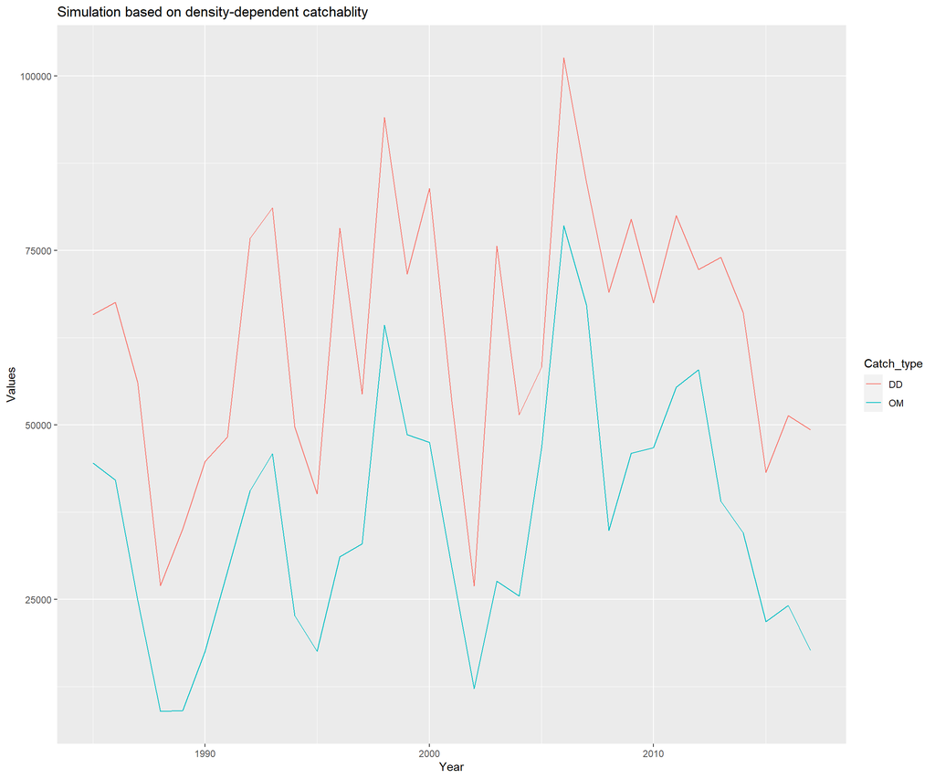

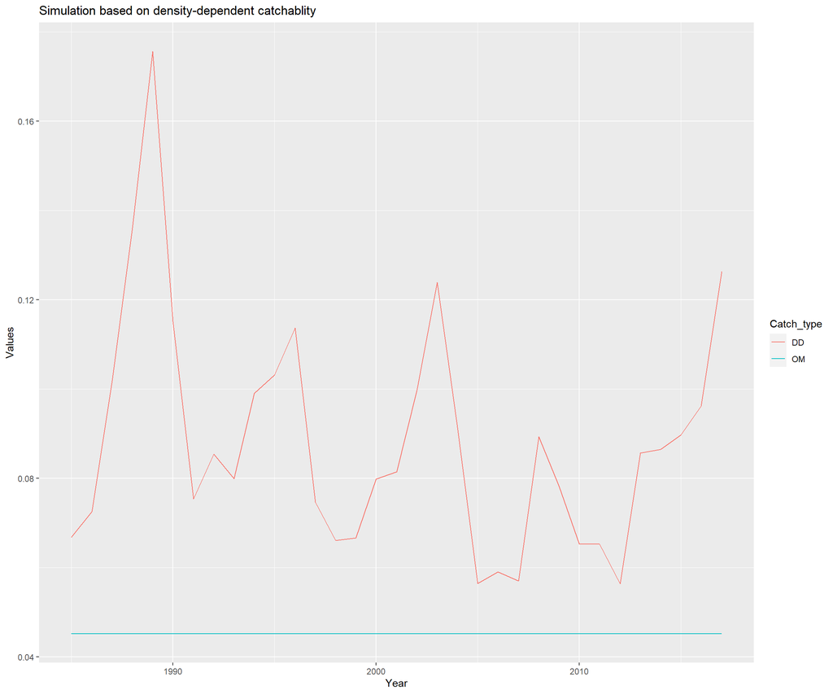

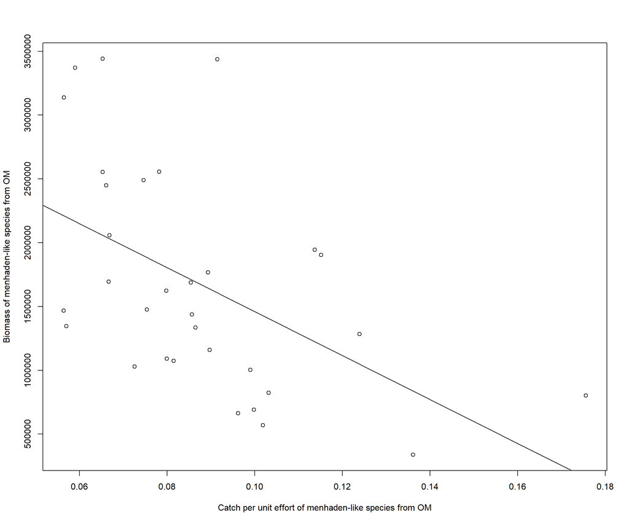

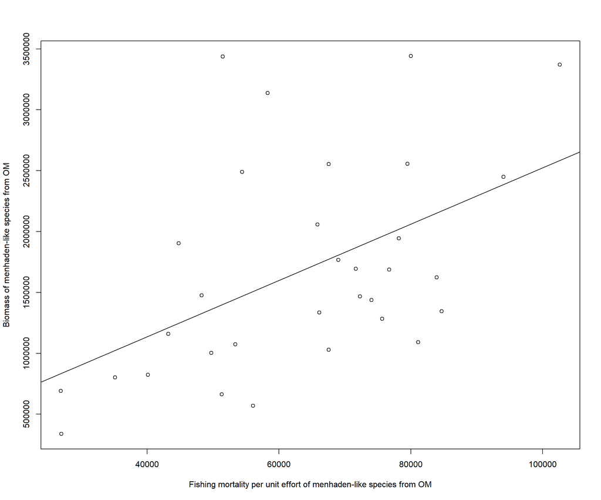